# 03 · Automatización de archivos con pathlib

## Automatización de archivos con pathlib

03 · RUTAS, ARCHIVOS Y OPERACIONES VERIFICABLES

Automatización de archivos  
con pathlib

**Teoría, demostraciones y laboratorio de archivos**

Caso conductor: observatorio territorial de deuda tributaria publicada.

Datos de aula completamente ficticios.

## P01 se convierte en operaciones concretas

Organizar evidencias requiere localizar archivos, distinguirlos de carpetas, inspeccionar sus nombres y aplicar cambios verificables.

Una ruta expresa dónde esperamos encontrar un recurso. El recurso puede no existir y el programa debe tratar esa situación.

**Resultado de este bloque**

Un inventario ordenado y operaciones individuales sobre archivos: escribir, copiar, renombrar, mover y eliminar ejemplos creados en el laboratorio.

Cada acción se contrasta con el estado esperado.

## Qué estudiaremos y qué queda después

| Aquí | En bloques posteriores |
| --- | --- |
| Rutas, nombres y consultas al sistema de archivos. | Procesamiento masivo y control de lotes (04). |
| Recorridos e inventarios de metadatos. | Políticas de copias y restauración (05). |
| Lectura y escritura de texto o bytes. | Organizador completo de documentos (06). |
| Operaciones individuales y condiciones previas. | Interpretación de Excel, PDF y otros formatos (07–11). |

No necesitamos pandas ni librerías de ofimática para esta práctica.

## Un sistema de archivos relaciona nombres y recursos

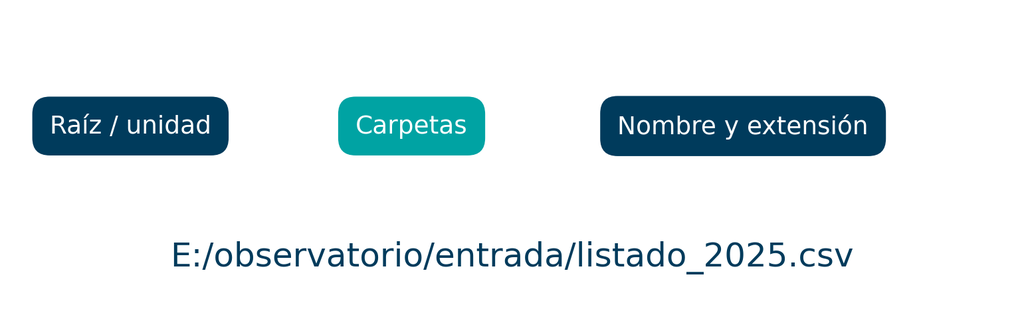

La ruta puede apuntar a un archivo, una carpeta, un enlace o una ubicación inexistente. Su texto no permite asegurar por sí solo qué hay en el destino.

## Path es un objeto que representa una ruta

```python
from pathlib import Path

ruta = Path("entrada") / "listado.csv"
print(ruta.name)
# listado.csv

print(ruta.suffix)
# .csv
```

El objeto ofrece operaciones sobre componentes y métodos que consultan o modifican el sistema de archivos.

Construir `Path("entrada/listado.csv")` no crea el archivo. Antes de ejecutar una operación conviene distinguir si solo calcula una ruta o realiza entrada/salida.

## Operaciones puras y operaciones con efectos

| Expresión | Efecto |
| --- | --- |
| `ruta.name`, `ruta.parent` | Calcula componentes. |
| `ruta.with_name("otro.txt")` | Devuelve otra ruta; no cambia archivos. |
| `ruta.exists()`, `ruta.stat()` | Consulta el sistema de archivos. |
| `ruta.mkdir()`, `ruta.write_text(...)` | Crea o modifica recursos. |
| `ruta.rename(destino)`, `ruta.unlink()` | Cambia la organización o elimina un archivo. |

Un método que devuelve una nueva ruta puede no haber ejecutado el cambio que su nombre sugiere.

## Path utiliza el sistema donde corre Python

`Path` construye una ruta concreta compatible con el sistema operativo del proceso Python. En Windows utiliza semántica Windows; en Linux utiliza semántica POSIX.

Un notebook alojado en Linux no accede a tu unidad E: por escribir su nombre. El archivo debe existir en el sistema o estar montado y accesible.

**Portabilidad**

Construye rutas desde una base configurada y componentes relativos. Evita repartir rutas absolutas de tu equipo por todas las celdas.

## Windows: barras, secuencias de escape y cadenas raw

```python
ruta_a = Path("E:/FCBQ/observatorio/entrada")
ruta_b = Path(r"E:\FCBQ\observatorio\entrada")

# En cadenas normales, \n y \t tienen significado especial.
# Una cadena raw no puede terminar con una única barra invertida.
```

Las cadenas raw evitan interpretar escapes. Usar barras `/` en rutas Windows también puede mejorar la lectura. Estas rutas concretas solo se abren en un entorno donde esa unidad exista.

## PureWindowsPath permite analizar una ruta sin abrirla

```python
from pathlib import PureWindowsPath

p = PureWindowsPath(
    "E:/observatorio/entrada/datos.csv"
)
print(p.drive)  # E:
print(p.name)   # datos.csv
print(p.parent)
```

Las clases `PureWindowsPath` y `PurePosixPath` calculan componentes y relaciones sin hacer operaciones de disco.

Son útiles para enseñar o interpretar rutas de otro sistema. No convierten un disco remoto en accesible ni permiten consultar su existencia.

## Rutas absolutas y relativas dependen de una referencia

```python
relativa = Path("entrada") / "datos.csv"
print(relativa.is_absolute())  # False

base = Path.cwd()
absoluta = base / relativa
print(absoluta.is_absolute())  # True
```

Una ruta relativa se interpreta desde el directorio de trabajo del proceso, no necesariamente desde la carpeta donde guardaste el notebook.

Cambiar de carpeta en el editor o lanzar Python desde otro terminal puede alterar ese contexto.

## Scripts y notebooks localizan su base de forma distinta

| Contexto | Referencia posible | Matiz |
| --- | --- | --- |
| Script `.py` | `Path(__file__).resolve().parent` | Ubicación del archivo que se está ejecutando. |
| Notebook | Una ruta configurada o `Path.cwd()` | `__file__` normalmente no está definido. |
| Laboratorio | `TemporaryDirectory()` | Raíz nueva, aislada y proporcionada por el sistema. |

No copies una solución con `__file__` a un notebook esperando que exista esa variable.

## El operador / compone componentes sin concatenar barras

```python
base = Path("observatorio")
entrada = base / "entrada"
ruta = entrada / "listado_2025.csv"

print(ruta.parent == entrada)
# True
```

Componer componentes evita gestionar manualmente el separador. También hace visible qué parte es la base y qué parte es un nombre.

La operación no modifica el objeto original ni comprueba que los componentes existan.

## Un componente absoluto puede descartar la base

```python
base = Path("/observatorio/entrada")
resultado = base / "/otra/carpeta"
# En POSIX: /otra/carpeta
```

Un componente absoluto redefine la ubicación. Para nombres recibidos de una entrada externa, valida que sean nombres simples o rutas relativas permitidas.

La barra de composición organiza texto de ruta. No es un mecanismo de confinamiento.

## Componentes que conviene conocer

| Propiedad | Ejemplo de `entrada/informe.final.txt` |
| --- | --- |
| `name` | `informe.final.txt` |
| `stem` | `informe.final` |
| `suffix` | `.txt` |
| `suffixes` | `[".final", ".txt"]` |
| `parent` | `entrada` |
| `parts` | Componentes de la ruta, incluida la raíz si la hay. |

## Las extensiones compuestas tienen matices

```python
p = Path("archivo.tar.gz")
print(p.suffix)    # .gz
print(p.stem)      # archivo.tar
print(p.suffixes)  # [".tar", ".gz"]

q = p.with_suffix(".txt")
print(q.name)  # archivo.tar.txt
```

La extensión final no describe necesariamente todo el formato. Cambiar el sufijo cambia el nombre calculado, no convierte ni descomprime el contenido.

El archivo `archivo.tar.gz` del laboratorio es texto ficticio con ese nombre; no intentaremos abrirlo como archivo comprimido.

## with_name y with_suffix no ejecutan un renombrado

```python
origen = Path("entrada/notas.txt")
propuesto = origen.with_name("notas_revisadas.txt")

print(origen.name)     # notas.txt
print(propuesto.name)  # notas_revisadas.txt
```

Todavía no hay un cambio de disco. Podemos utilizar la ruta propuesta para mostrar una previsualización, comprobar el destino y decidir si ejecutar una acción.

## Una regla de nombres debe servir al proceso

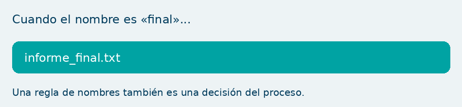

Una convención necesita expresar información útil: edición, tipo y versión cuando corresponda. Evita que la automatización invente un significado a partir de nombres ambiguos.

## Nombres portables y diferencias de mayúsculas

Windows y Linux pueden tratar de forma distinta las mayúsculas y los nombres reservados. No asumas que `Informe.txt` y `informe.txt` siempre son archivos diferentes.

En la práctica rechazamos separadores, controles, espacios extremos y nombres reservados habituales de Windows.

**Política conservadora de aula**

`resumen_2025.txt`: permitido. `../resumen.txt`: rechazado. `CON.txt`: rechazado.

No es una lista exhaustiva de restricciones de todos los sistemas.

## cwd, home y expanduser resuelven necesidades distintas

```python
trabajo = Path.cwd()
personal = Path.home()
configurada = Path("~/observatorio").expanduser()
```

`cwd()` indica el directorio de trabajo. `home()` consulta la carpeta personal. `expanduser()` interpreta `~` al principio de una ruta.

La práctica no usa la carpeta personal para crear ni borrar archivos. Su raíz se genera mediante una carpeta temporal nueva.

## resolve puede consultar el estado real de la ruta

```python
resuelta = ruta.resolve()

# Exige que exista el recorrido completo:
existente = ruta.resolve(strict=True)
```

Resolver convierte la ruta en absoluta y trata componentes como `..` y enlaces simbólicos según el sistema.

Con `strict=True`, una ruta inexistente provoca error. Con el valor por defecto puede quedar una parte que todavía no existe.

## relative_to e is_relative_to trabajan sobre rutas

```python
base = Path("/observatorio")
p = base / "entrada" / "datos.csv"

print(p.relative_to(base))
# entrada/datos.csv
print(p.is_relative_to(base))
# True
```

La relación es sintáctica si no hemos resuelto antes las rutas. `relative_to()` falla si no puede construir esa relación. No demuestra que un enlace permanezca dentro de la base.

## Un prefijo de texto no comprueba pertenencia

```python
base = "/datos/auditoria"
otra = "/datos/auditoria_ajena/datos.txt"

print(otra.startswith(base))
# True, pero no pertenece a esa carpeta
```

Las rutas tienen componentes. Un prefijo de cadena puede coincidir con otro nombre de carpeta.

En la práctica resolvemos la raíz y contrastamos pertenencia por componentes. También rechazamos enlaces en las operaciones y segmentos `..`.

## La práctica crea un entorno nuevo en cada ejecución

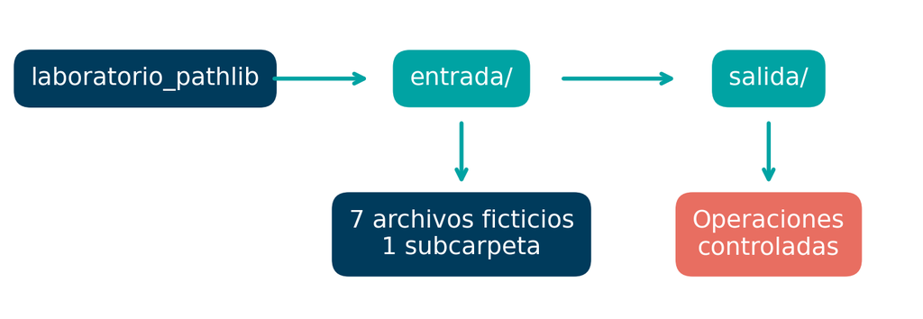

La carpeta del laboratorio se crea con `exist_ok=False`. Si ya existe, la función falla en lugar de vaciar o reutilizar un destino desconocido.

## TemporaryDirectory da una raíz para experimentar

```python
from tempfile import TemporaryDirectory

with TemporaryDirectory(prefix="curso_pathlib_") as tmp:
    entorno = crear_entorno(tmp)
    raiz = entorno["raiz"]
    print(raiz)
    # Trabajamos aquí con archivos ficticios.
```

Al salir del contexto se elimina ese directorio temporal. En los notebooks mantenemos el objeto vivo para poder inspeccionar resultados mientras trabajamos.

## mkdir necesita una política para carpetas existentes

| Opción | Qué cambia |
| --- | --- |
| `mkdir()` | Crea una carpeta; falla si no puede o ya existe. |
| `parents=True` | Permite crear padres que faltan. |
| `exist_ok=True` | Permite que la carpeta ya exista. |
| `exist_ok=False` | Hace visible una colisión. |

Permitir una carpeta existente no demuestra que esté vacía ni que pertenezca a esta ejecución. Un archivo con ese nombre sigue siendo un problema.

## exists, is_file e is_dir responden preguntas diferentes

```python
print(entrada.exists())
print(entrada.is_dir())
print((entrada / "notas.txt").is_file())
print((entrada / "ausente.txt").exists())
```

Existir no implica ser un archivo regular. Una ruta puede ser una carpeta o un enlace. Algunas consultas siguen enlaces y un enlace roto puede dar una respuesta distinta de la que esperas.

Los errores por permisos o estado del sistema requieren tratamiento; no todos equivalen a «no existe».

## iterdir enumera hijos inmediatos

```python
hijos = sorted(entrada.iterdir(), key=lambda p: p.name)
for hijo in hijos:
    print(hijo.name, hijo.is_dir())
```

No recorre subcarpetas. El orden que entrega el sistema no es una regla de negocio; ordenamos explícitamente para enseñar y comparar resultados.

El listado puede cambiar si otro proceso modifica la carpeta mientras lo recorremos.

## glob selecciona por patrón, no por contenido

```python
rutas = list(entrada.glob("*.csv"))

# Filtro explícito sobre archivos directos:
csvs = sorted(
    p for p in entrada.iterdir()
    if p.is_file() and p.suffix.lower() == ".csv"
)
```

El comportamiento de mayúsculas en patrones depende del entorno. El laboratorio incluye una extensión `.CSV` para hacerlo visible.

El segundo ejemplo define explícitamente una comparación de extensión en minúsculas, sin cambiar el nombre real del archivo.

## rglob recorre el árbol y exige filtrar resultados

```python
archivos = sorted(
    p for p in entrada.rglob("*")
    if not p.is_symlink() and p.is_file()
)
```

Los patrones pueden devolver carpetas y otros recursos. La práctica inventaría solo archivos regulares, excluye enlaces y ordena rutas.

Un árbol grande puede requerir tiempo y permisos sobre varias ubicaciones; una consulta incompleta no debe presentarse como inventario completo.

El inventario guiado recorre carpetas con `iterdir()` explícito para no depender de errores que `glob()` o `rglob()` puedan omitir.

## stat aporta metadatos, no interpretación del documento

```python
info = (entrada / "notas.txt").stat()
print(info.st_size)   # bytes

fecha = datetime.fromtimestamp(
    info.st_mtime, tz=timezone.utc
)
print(fecha.isoformat())
```

El tamaño se expresa en bytes. La fecha de modificación se convierte explícitamente a UTC para documentar la referencia temporal.

La fecha de creación no tiene una propiedad portátil equivalente en todos los sistemas. `st_ctime` no debe interpretarse universalmente como creación.

## Bytes, KiB y MiB necesitan unidades explícitas

$$B_{total}=\sum_{i=1}^{N} B_i\qquad MiB=\frac{B_{total}}{1024^2}$$

Un archivo vacío tiene cero bytes, pero sigue siendo un archivo. Para unidades decimales, MB usa $10^6$ bytes; para unidades binarias, MiB usa $2^{20}$.

No confundas cantidad de archivos, bytes de contenido y espacio ocupado físicamente en disco. Son métricas relacionadas pero diferentes.

## Un inventario expresa el contrato de exploración

| Campo | Significado |
| --- | --- |
| `ruta` | Ruta relativa a la raíz del laboratorio, en formato con `/`. |
| `nombre` | Nombre completo, sin modificarlo. |
| `extension` | Sufijo final en minúsculas para comparar. |
| `bytes` | Tamaño lógico de contenido. |
| `modificado_utc` | Modificación con zona UTC explícita. |

El inventario inicial contiene siete archivos. Guardamos rutas relativas para que la ubicación temporal aleatoria no cambie la identificación de cada ejemplo.

## Qué encuentra el inventario inicial

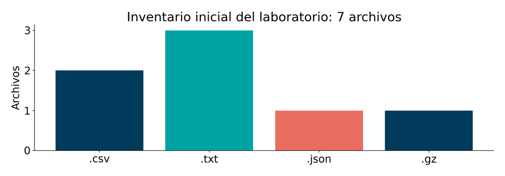

Las dos extensiones CSV se agrupan mediante `suffix.lower()`. El sufijo `.gz` del nombre compuesto no implica que el contenido sea realmente un comprimido.

## read_text decodifica el contenido con una codificación

```python
texto = (entrada / "notas.txt").read_text(encoding="utf-8")
print(texto)
```

Leer texto supone convertir bytes en caracteres. La codificación debe corresponder al archivo. Una codificación equivocada puede producir un error o caracteres incorrectos.

`read_text()` carga el contenido completo en memoria; no es la elección adecuada para cualquier tamaño de archivo.

## write_text reemplaza; el modo x crea exclusivamente

| Operación | Si el archivo existe |
| --- | --- |
| `ruta.write_text(texto, encoding="utf-8")` | Sustituye su contenido. |
| `ruta.open("w", encoding="utf-8")` | Trunca y escribe contenido nuevo. |
| `ruta.open("a", encoding="utf-8")` | Añade al final. |
| `ruta.open("x", encoding="utf-8")` | Falla con FileExistsError. |

En la práctica usamos creación exclusiva para nuevas salidas. El hecho de que un archivo existente esté vacío no autoriza sobrescribirlo.

## with open cierra el recurso y permite leer por líneas

```python
with (entrada / "listado_2024.csv").open(
    "r", encoding="utf-8"
) as archivo:
    for linea in archivo:
        print(linea.rstrip("\n"))
```

El contexto cierra el archivo incluso cuando aparece una excepción. Recorrer líneas evita solicitar todo el texto de una vez, aunque una línea individual todavía puede ser grande.

## read_bytes y write_bytes operan con contenido binario

```python
contenido = (entrada / "notas.txt").read_bytes()
print(type(contenido))  # bytes

texto = contenido.decode("utf-8")
```

Los bytes no requieren decidir una codificación para leerse como bytes. Interpretarlos como texto sí la requiere.

`write_bytes()` puede sobrescribir y carga el contenido que le proporcionas. Para crear un destino binario exclusivamente utilizamos `open("xb")`.

## Path representa rutas; shutil complementa las copias

```python
with origen.open("rb") as fuente, \
     destino.open("xb") as salida:
    shutil.copyfileobj(fuente, salida)
```

La versión base Python 3.11 no incluye métodos `Path.copy()` o `Path.move()`. Usamos herramientas disponibles en esa versión.

La copia conserva contenido en la demostración. No promete propietarios, ACL ni todos los metadatos. El destino debe tener una carpeta padre existente.

## rename puede tener efectos distintos entre sistemas

`origen.rename(destino)` solicita un cambio de nombre o ubicación. Si existe el destino, el comportamiento depende del sistema y del tipo de recurso. En POSIX puede sustituir un archivo existente; Windows suele rechazar ese caso.

**Política del laboratorio**

Comprobar colisión y previsualizar por defecto. La ejecución se limita a la carpeta temporal, en un mismo sistema de archivos y sin otros escritores.

## Mover entre carpetas también necesita una frontera

```python
destino = salida / "notas_ordenadas.txt"
plan = trasladar_local(
    raiz, origen, destino, simular=True
)
```

El movimiento local de esta práctica utiliza rename dentro de la misma raíz temporal.

Mover entre unidades puede requerir copiar y borrar con otras garantías y fallos parciales. `shutil.move()` ofrece ese tipo de operación, pero no lo convertimos en un flujo de producción en este tema.

## Una previsualización permite comprobar intención antes del cambio

```python
plan = renombrar_local(
    raiz, copia, "notas_revisadas.txt", simular=True
)
print(plan["ejecutado"])  # False
assert copia.exists()
```

El plan muestra origen y destino. No reserva el nombre ni garantiza que el estado siga igual al ejecutar después. Se repiten las validaciones en la llamada que realiza el cambio.

## Una colisión merece una decisión explícita

Dos archivos pueden proponer el mismo nombre. Las opciones incluyen detener, revisar, conservar versiones o aplicar una convención acordada.

La práctica se detiene con `FileExistsError`; no inventa un sufijo ni reemplaza silenciosamente.

**Caso de aula**

Copiar notas a un destino nuevo funciona.

Intentar copiar otra vez al mismo nombre falla y conserva el primer contenido.

Ese fallo es una evidencia esperada del contrato.

## Comprobar y usar son pasos separados

$$t_{comprobacion}<t_{operacion}$$

Entre ambos instantes puede cambiar el archivo o aparecer el destino. Una comprobación previa de `exists()` no convierte un rename en una operación exclusiva.

El modo `x` protege la creación del nombre al abrir. Aun así, una escritura puede fallar parcialmente. La raíz privada y la ausencia de concurrencia son supuestos de la práctica, no garantías universales.

## El control de alcance tiene varias comprobaciones

El helper didáctico comprueba que la base existe, exige pertenencia por componentes y rechaza segmentos `..` y enlaces simbólicos en la ruta. Las operaciones actúan solo sobre archivos del entorno temporal.

**Límite de la comprobación**

No es una frontera de seguridad frente a procesos hostiles que puedan modificar el árbol. Para ese problema se necesitan controles del sistema operativo y otro diseño de acceso.

## unlink elimina una entrada de archivo

```python
resultado = borrar_demo(raiz, archivo_demo, simular=True)
assert archivo_demo.exists()

# Solo un ejemplo creado para borrar en el laboratorio:
# borrar_demo(raiz, archivo_demo, simular=False)
```

`unlink()` no equivale a enviar a la papelera. La función de aula solo admite archivos regulares y simula por defecto. El borrado real se practica sobre un archivo que acabamos de crear con ese propósito.

## rmdir solo elimina carpetas vacías

```python
carpeta_demo = salida / "carpeta_vacia"
carpeta_demo.mkdir()
carpeta_demo.rmdir()
assert not carpeta_demo.exists()
```

Si la carpeta contiene un archivo, `rmdir()` falla. No utilizamos borrado recursivo sobre carpetas elegidas por el usuario. La retirada global de la práctica se limita al contenedor que creó `TemporaryDirectory`.

## Los errores indican condiciones distintas

| Excepción | Situación habitual |
| --- | --- |
| FileNotFoundError | Falta el origen o la carpeta padre. |
| FileExistsError | Hay un nombre de salida que no se puede reutilizar. |
| PermissionError | El proceso no tiene permisos suficientes. |
| IsADirectoryError / NotADirectoryError | El tipo de recurso no es el requerido. |
| UnicodeDecodeError | Los bytes no se interpretan con esa codificación. |

No se capturan todas con un «continuar» genérico que presente un resultado incompleto como correcto.

## El recorrido guiado conserva las entradas

Primero generamos el entorno y su inventario. Leemos un texto y escribimos una salida nueva. Copiamos `notas.txt` a salida y operamos después sobre esa copia.

Así el archivo original sigue disponible para contrastar contenido y repetir ejemplos.

**Estado esperado**

Entrada: los siete archivos originales.

Salida: archivos creados por las demostraciones.

Solo se elimina un archivo de descarte dedicado a esa demostración.

## Repetir una celda puede encontrar una salida anterior

La creación exclusiva permite detectar que una celda ya escribió su resultado. Volver a ejecutarla puede producir una colisión esperada.

Para repetir la sesión completa, se crea un entorno temporal nuevo. No se reinicia borrando una carpeta real.

**Regla de trabajo**

Si repites una demostración de escritura, revisa el estado y el nombre.

No cambies a modo `w` solo para que desaparezca una colisión.

## Orden reproducible y metadatos cambiantes

Ordenamos el inventario por ruta y comprobamos nombres y contenido. El nombre del contenedor temporal y las fechas cambian entre sesiones.

La igualdad que interesa depende del requisito: contenido idéntico, misma estructura o la misma lista ordenada no son equivalentes a identidad completa del sistema de archivos.

**Comprobación del ejemplo**

Dos CSV, tres TXT, un JSON y un nombre con sufijo GZ.

Un archivo vacío sigue contando.

No exigimos que las fechas sean iguales.

## El coste de recorrer depende del árbol y de las consultas

$$N=\text{archivos y carpetas visitados}\qquad B=\text{bytes leidos}$$

Consultar nombres y metadatos no equivale a leer todo el contenido. Un inventario puede consultar muchos recursos aunque sus archivos sean pequeños.

`read_text()` o `read_bytes()` materializan contenido completo. Leer por líneas o copiar por flujo limita cuánto contenido solicitamos de una vez, sin eliminar todos los costes.

## Aplicación a la ficha de P01

| Requisito del proceso | Operación que lo hace observable |
| --- | --- |
| Localizar evidencias de una edición. | Componer base y rutas relativas; recorrer con criterio. |
| Saber qué se recibió. | Inventariar nombres, tamaños y fechas. |
| Conservar el nombre propuesto antes de actuar. | `with_name()` y previsualización. |
| Evitar un reemplazo accidental en la práctica. | Escritura exclusiva y detección de colisiones. |
| Mantener evidencia de la operación. | Devolver origen, destino y estado de ejecución. |

## Doce ejercicios para construir una comprensión verificable

| Ejercicios | Qué se contrasta |
| --- | --- |
| 01–03 | Componentes, rutas Windows puras y cambios sin efectos. |
| 04–06 | Hijos, búsqueda explícita e inventario recursivo. |
| 07–09 | Lectura, escritura exclusiva, copia y simulación. |
| 10–12 | Movimiento, colisiones, alcance y borrado de un ejemplo. |

Los notebooks incluyen una guía completa antes de los ejercicios. Las tareas no necesitan archivos externos y usan nombres de salida distintos.

## Las comprobaciones deben mirar el efecto correcto

```python
assert original.exists()
assert copia.exists()
assert original.read_bytes() == copia.read_bytes()

assert plan["ejecutado"] is False
```

En estos archivos pequeños comparamos bytes para comprobar la copia. Tras una simulación verificamos que el origen sigue presente y que no apareció el destino.

Tras un movimiento real, el destino existe y el origen anterior deja de existir. El objeto Path anterior no se actualiza automáticamente.

## Actividad de diagnóstico: tres problemas de intención

```python
base = Path("entrada")
destino = base / "/salida/resumen.txt"
propuesto = destino.with_name("resumen_final.txt")
destino.write_text("resultado")
```

¿Qué ocurre con la base? ¿Se ha renombrado algún archivo? ¿Qué pasaría si destino ya existiera?

En POSIX la parte absoluta descarta la base. `with_name()` solo calcula otra ruta. `write_text()` puede sobrescribir y no crea automáticamente las carpetas padre.

## Qué hemos construido y qué viene después

Ya podemos identificar rutas, inspeccionar un árbol y ejecutar cambios individuales con un contrato claro. El inventario separa nombre, tipo y metadatos; la práctica distingue intención, simulación y efecto real.

El siguiente bloque combinará estas operaciones con **procesamiento masivo de documentos**: selección de lotes, resultados por elemento y tratamiento de incidencias.

**Pregunta de salida**

¿Qué comprobación harías antes de renombrar un archivo y qué estado verificarías después?

## El inventario también contiene información del proyecto

Una ruta o un nombre puede revelar cliente, edición, expediente o identidad de una persona. Para el proyecto real, define quién necesita recibir el inventario y qué campos son necesarios para su finalidad.

**Decisión de diseño**

Utilizar rutas relativas evita divulgar parte de la estructura del equipo. En este laboratorio todos los nombres son ficticios y no se transmite el inventario a servicios externos.

## Fuentes y versión de referencia

- [Python 3.11 · pathlib](https://docs.python.org/3.11/library/pathlib.html).
- [Python 3.11 · shutil](https://docs.python.org/3.11/library/shutil.html).
- [Python 3.11 · tempfile](https://docs.python.org/3.11/library/tempfile.html).
- [Python 3.11 · open y modos de archivo](https://docs.python.org/3.11/library/functions.html#open).

La práctica se diseña para Python 3.11 o superior, usando la API disponible en 3.11. No se utilizan métodos nuevos de Path para copiar o mover que requieran versiones posteriores.

Gráficos y GIF originales. Logos y fondo reutilizados del material de referencia. Revisión: **3 de noviembre de 2026**.